# Collect USGS stream observations and build a local database.

James McCreight

2015-05-20

# Background

USGS streamflow observations are a primary source of hydrologic information and often used for validation and calibration of hydrlogic models. Recently, web services have been developed at [*NWIS*](http://waterdata.usgs.gov/nwis) and the [*dataRetrieval*](http://cran.r-project.org/web/packages/dataRetrieval/index.html) R package have emerged to make it easy to get USGS data into R.

This vignette demonstrates some rwrfhydro tools to collect, store, and manipulate USGS data. These are built ontop of the dataRetrieval package. As with the rest of the rwrfhydro package, development is on-going. Currently, we focus on instantaneous stream data observations from NWIS. The tools build a local database which has not yet been developed to allow appending (i.e. only grabbing and adding) observations beyond those existing locally. But there is enough existing functionality to make its exposition worthwhile. Check for updates to this vignette.

The fundamental layout of the local database is simply a directory containing:

- Metadata data base (metaDB): Organized hierarchically by HUC8 -> product id -> siteInfo, variableInfo, statisticInfo where the last three are information fields returned by dataRetrieval::readNWISuv. The information in this file is simply the aggregation of the metadata from all the data files also contained in the same directory.
- Individual data files collected by HUC8: These contain both the meta data for the HUC8 (aggregated in the metadata DB) and all the previously retrieved data for the HUC8.

Generally, there are two basic kinds of functions: “Get” and “Query”. Get functions use dataRetrieval functions to actually go out to NWIS and “get” data and metadata. Query functions query the local database. There are exceptions to this.

# Setup

Load the rwrfhydro package.

```r
library("rwrfhydro")
```

This is the path to the directory where you want your database to be built:

```r
 dbPath <- '~/wrfHydroTestCases/usgsDb/'
```

# Discover gage locations, get data, and save to local database.

Perhaps you know the lat/lon of a gage (e.g. from frxst_pts_out.txt) and you need the HUC8. The `within` argument is taken to be in decimal degrees.

```r
stnDf <- FindUsgsStns(stnLon=254.67374999999998408,
                      stnLat=40.018666670000001773,
                      within=.001)
str(stnDf)
```

```
## 'data.frame':    1 obs. of  12 variables:
##  $ stnLon       : num 255
##  $ stnLat       : num 40
##  $ within       : num 0.001
##  $ siteType     : chr "ST"
##  $ hasDataTypeCd: chr "iv"
##  $ agency_cd    : chr "USGS"
##  $ site_no      : chr "06727500"
##  $ station_nm   : chr "FOURMILE CREEK AT ORODELL, CO"
##  $ site_tp_cd   : chr "ST"
##  $ dec_lat_va   : num 40
##  $ dec_long_va  : num -105
##  $ queryTime    : POSIXct, format: "2015-05-20 09:31:53"
```

Now you have the site_no or station ID number, “06727500”. You could have also used `FindUsgsStns()` to reveal the gages in the HUC8, if you knew the HUC8 code. Because we organize the database by HUC8, we have a function to get HUC8 from station id. Then we get the above information for all locations in the HUC8.

```r
huc8 <- GetSiteHuc(stnDf$site_no)
str(FindUsgsStns(huc=huc8))
```

```
## 'data.frame':    8 obs. of  10 variables:
##  $ huc8         : Factor w/ 1 level "10190005": 1 1 1 1 1 1 1 1
##  $ siteType     : chr  "ST" "ST" "ST" "ST" ...
##  $ hasDataTypeCd: chr  "iv" "iv" "iv" "iv" ...
##  $ agency_cd    : chr  "USGS" "USGS" "USGS" "USGS" ...
##  $ site_no      : chr  "06727410" "06730160" "06727500" "06730200" ...
##  $ station_nm   : chr  "FOURMILE CREEK AT LOGAN MILL ROAD NEAR CRISMAN, CO" "FOURMILE CANYON CREEK NEAR SUNSHINE, CO" "FOURMILE CREEK AT ORODELL, CO" "BOULDER CREEK AT NORTH 75TH ST. NEAR BOULDER, CO" ...
##  $ site_tp_cd   : chr  "ST" "ST" "ST" "ST" ...
##  $ dec_lat_va   : num  40 40.1 40 40.1 40.1 ...
##  $ dec_long_va  : num  -105 -105 -105 -105 -105 ...
##  $ queryTime    : POSIXct, format: "2015-05-20 09:31:57" "2015-05-20 09:31:57" "2015-05-20 09:31:57" "2015-05-20 09:31:57" ...
```

FindUsgsStns is a wrapper on dataRetrieval::whatNWISsites which has been written to focus on instantaneous values. (It is worth noting the flexibility and generality of the underlying function.)

Now pull the data for this HUC8. Currently, this grabs all available products for the HUC. Note that the HUC data are organized by product code (e.g. `00060`) then by `data` and `meta` in the returned list. (Also note that this command sometimes fails on the remote end and may need to be rerun.) In `meta`, siteInfo is the meta that we use in querying the local data base in commands shown below.

```r
coData <- GetUsgsHucData(huc=huc8)
str(coData)
```

```r
str(coData)
```

```
## List of 2
##  $ 00060:List of 2
##   ..$ data:'data.frame': 1265329 obs. of  6 variables:
##   .. ..$ agency_cd       : chr [1:1265329] "USGS" "USGS" "USGS" "USGS" ...
##   .. ..$ site_no         : chr [1:1265329] "06724970" "06724970" "06724970" "06724970" ...
##   .. ..$ dateTime        : POSIXct[1:1265329], format: "2014-03-06 07:00:00" "2014-03-06 07:10:00" "2014-03-06 07:20:00" "2014-03-06 07:30:00" ...
##   .. ..$ tz_cd           : chr [1:1265329] "UTC" "UTC" "UTC" "UTC" ...
##   .. ..$ X_00060_00011_cd: chr [1:1265329] "A" "A" "A" "A" ...
##   .. ..$ X_00060_00011   : num [1:1265329] 11 11 11 12 12 13 13 13 13 13 ...
##   ..$ meta:List of 3
##   .. ..$ siteInfo     :'data.frame': 8 obs. of  46 variables:
##   .. .. ..$ site_no              : chr [1:8] "06724970" "06725450" "06727410" "06727500" ...
##   .. .. ..$ agency_cd            : chr [1:8] "USGS" "USGS" "USGS" "USGS" ...
##   .. .. ..$ dec_lat_va           : num [1:8] 40.1 40.2 40 40 40.1 ...
##   .. .. ..$ dec_long_va          : num [1:8] -105 -105 -105 -105 -105 ...
##   .. .. ..$ huc_cd               : chr [1:8] "10190005" "10190005" "10190005" "10190005" ...
##   .. .. ..$ site_tp_cd           : chr [1:8] "ST" "ST" "ST" "ST" ...
##   .. .. ..$ state_cd             : chr [1:8] "08" "08" "08" "08" ...
##   .. .. ..$ station_nm           : chr [1:8] "LEFT HAND CREEK AT HOVER ROAD NEAR LONGMONT, CO" "ST. VRAIN CREEK BELOW LONGMONT, CO" "FOURMILE CREEK AT LOGAN MILL ROAD NEAR CRISMAN, CO" "FOURMILE CREEK AT ORODELL, CO" ...
##   .. .. ..$ tz_cd                : chr [1:8] "MST" "MST" "MST" "MST" ...
##   .. .. ..$ lat_va               : num [1:8] 400803 400927 400231 400107 400327 ...
##   .. .. ..$ long_va              : num [1:8] 1050751 1050055 1052154 1051934 1052056 ...
##   .. .. ..$ coord_meth_cd        : chr [1:8] "N" "N" "M" "N" ...
##   .. .. ..$ coord_acy_cd         : chr [1:8] "M" "5" "1" "5" ...
##   .. .. ..$ coord_datum_cd       : chr [1:8] "NAD83" "NAD83" "NAD83" "NAD83" ...
##   .. .. ..$ dec_coord_datum_cd   : chr [1:8] "NAD83" "NAD83" "NAD83" "NAD83" ...
##   .. .. ..$ district_cd          : chr [1:8] "08" "08" "08" "08" ...
##   .. .. ..$ county_cd            : chr [1:8] "013" "123" "013" "013" ...
##   .. .. ..$ country_cd           : chr [1:8] "US" "US" "US" "US" ...
##   .. .. ..$ land_net_ds          : chr [1:8] "  SWSWS16 T02N  R69W  6" "  NWNWS09 T002N R068W" "  NWNES20 T01N  R71W" "  NWSES27 T001N R071W" ...
##   .. .. ..$ map_nm               : chr [1:8] "HYGIENE, CO" "LONGMONT, CO" "BOULDER, CO" "BOULDER, CO" ...
##   .. .. ..$ map_scale_fc         : chr [1:8] "  24000" "  24000" "  24000" "  24000" ...
##   .. .. ..$ alt_va               : num [1:8] 4994 4852 6341 5750 6639 ...
##   .. .. ..$ alt_meth_cd          : chr [1:8] "N" "M" "N" "M" ...
##   .. .. ..$ alt_acy_va           : num [1:8] 4.3 10 4.3 15 4.3 10 10 4.3
##   .. .. ..$ alt_datum_cd         : chr [1:8] "NAVD88" "NGVD29" "NAVD88" "NGVD29" ...
##   .. .. ..$ basin_cd             : chr [1:8] "06" "06" "" "06" ...
##   .. .. ..$ topo_cd              : chr [1:8] "" "" "C" "" ...
##   .. .. ..$ instruments_cd       : chr [1:8] "YNNNYNNNNNNNNNNNNNNNNNNNNNNNNN" "NNNNYNNNNNNNNNNNNNNNNNNNNNNNNN" "NNNNYNYNNYNNNNNNNNNNNNNNNNNNNN" "NNNNYNYNNYNNNNNNNNNNNNNNNNNNNN" ...
##   .. .. ..$ construction_dt      : chr [1:8] "" "" "" "" ...
```

[output cut: 81 more lines]

```
##   .. .. ..$ startTime            : POSIXct[1:6], format: "2014-12-30 07:00:00" "2015-03-27 16:15:00" "2015-03-27 19:35:00" "2014-12-30 07:00:00" ...
##   .. .. ..$ endTime              : POSIXct[1:6], format: "2015-04-29 21:10:00" "2015-04-29 21:10:00" "2015-04-29 21:20:00" "2015-04-29 21:15:00" ...
##   .. ..$ variableInfo :'data.frame': 1 obs. of  6 variables:
##   .. .. ..$ parameterCd   : chr "00065"
##   .. .. ..$ parameter_nm  : chr "Gage height, ft"
##   .. .. ..$ parameter_desc: chr "Gage height, feet"
##   .. .. ..$ valueType     : chr "Derived Value"
##   .. .. ..$ param_units   : chr "ft"
##   .. .. ..$ noDataValue   : logi NA
##   .. ..$ statisticInfo:'data.frame': 1 obs. of  2 variables:
##   .. .. ..$ statisticName: chr ""
##   .. .. ..$ statisticCd  : chr "00011"
##  - attr(*, "split_type")= chr "data.frame"
##  - attr(*, "split_labels")='data.frame': 2 obs. of  1 variable:
##   ..$ parm_cd: chr [1:2] "00060" "00065"
```

Now save this data to the local database. Note that this also could have been achieved by specifying the `outPath` argument to `GetUsgsHucData`.

```r
coFiles <- SaveHucData(coData, outPath=dbPath)
coFiles
```

For a little more variety of HUCs in the database, let’s also grab the following HUC.

```r
filesAL <- GetUsgsHucData(huc='03160203', outPath=dbPath) ## Satilpa, AL
```

# Query the local data

Now we work entirely locally, having grabbed the data of interest. For all HUC8 and products, any of the siteInfo metadata can be retrieved from the local DB. Note that the same site is repeated for multiple products.

```r
QuerySiteInfo(c('station_nm','site_no','dec_lat_va','dec_long_va'), path=dbPath)
```

| station_nm | site_no | dec_lat_va | dec_long_va | product | HUC8 |
| --- | --- | --- | --- | --- | --- |
| LEFT HAND CREEK AT HOVER ROAD NEAR LONGMONT, CO | 06724970 | 40.13428 | -105.13082 | 00060 | 10190005 |
| ST. VRAIN CREEK BELOW LONGMONT, CO | 06725450 | 40.15742 | -105.01539 | 00060 | 10190005 |
| FOURMILE CREEK AT LOGAN MILL ROAD NEAR CRISMAN, CO | 06727410 | 40.04203 | -105.36492 | 00060 | 10190005 |
| FOURMILE CREEK AT ORODELL, CO | 06727500 | 40.01867 | -105.32625 | 00060 | 10190005 |
| FOURMILE CANYON CREEK NEAR SUNSHINE, CO | 06730160 | 40.05761 | -105.34878 | 00060 | 10190005 |
| BOULDER CREEK AT NORTH 75TH ST. NEAR BOULDER, CO | 06730200 | 40.05165 | -105.17888 | 00060 | 10190005 |
| BOULDER CREEK AT MOUTH NEAR LONGMONT, CO | 06730500 | 40.13878 | -105.02022 | 00060 | 10190005 |
| ST VRAIN CR BLW BOULDER CR AT HWY 119 NR LONGMONT | 06730525 | 40.16035 | -105.00783 | 00060 | 10190005 |
| LEFT HAND CREEK AT HOVER ROAD NEAR LONGMONT, CO | 06724970 | 40.13428 | -105.13082 | 00065 | 10190005 |
| FOURMILE CREEK AT ORODELL, CO | 06727500 | 40.01867 | -105.32625 | 00065 | 10190005 |
| FOURMILE CANYON CREEK NEAR SUNSHINE, CO | 06730160 | 40.05761 | -105.34878 | 00065 | 10190005 |
| BOULDER CREEK AT NORTH 75TH ST. NEAR BOULDER, CO | 06730200 | 40.05165 | -105.17888 | 00065 | 10190005 |
| BOULDER CREEK AT MOUTH NEAR LONGMONT, CO | 06730500 | 40.13878 | -105.02022 | 00065 | 10190005 |
| ST VRAIN CR BLW BOULDER CR AT HWY 119 NR LONGMONT | 06730525 | 40.16035 | -105.00783 | 00065 | 10190005 |
| TOMBIGBEE R AT COFFEEVILLE L&D NR COFFEEVILLE, AL. | 02469761 | 31.75849 | -88.12918 | 00060 | 03160203 |
| SATILPA CREEK NEAR COFFEEVILLE AL | 02469800 | 31.74432 | -88.02251 | 00060 | 03160203 |
| BASSETT CREEK AT US HIGHWAY 43 NR THOMASVILLE, AL. | 02470072 | 31.86404 | -87.74722 | 00060 | 03160203 |
| TOMBIGBEE R AT COFFEEVILLE L&D NR COFFEEVILLE, AL. | 02469761 | 31.75849 | -88.12918 | 00065 | 03160203 |
| TOMBIGBEE R BL COFFEEVILLE L&D NEAR COFFEEVILLE | 02469762 | 31.75710 | -88.12501 | 00065 | 03160203 |
| SATILPA CREEK NEAR COFFEEVILLE AL | 02469800 | 31.74432 | -88.02251 | 00065 | 03160203 |
| TOMBIGBEE RIVER AT STEAMPLANT NR LEROY, AL | 02470050 | 31.48600 | -87.90889 | 00065 | 03160203 |
| BASSETT CREEK AT US HIGHWAY 43 NR THOMASVILLE, AL. | 02470072 | 31.86404 | -87.74722 | 00065 | 03160203 |
| TOMBIGBEE R AT COFFEEVILLE L&D NR COFFEEVILLE, AL. | 02469761 | 31.75849 | -88.12918 | 45592 | 03160203 |

Say you just want Orodell and you want your code to be readable: translate the name to the code with QuerySiteName (which translates both ways).

```r
dataOrodell <- QuerySiteData(QuerySiteName("FOURMILE CREEK AT ORODELL, CO", path=dbPath),
                             product='00060', path=dbPath)
str(dataOrodell)
```

```
## 'data.frame':    212472 obs. of  5 variables:
##  $ site_no : chr  "06727500" "06727500" "06727500" "06727500" ...
##  $ dateTime: POSIXct, format: "2011-04-01 06:00:00" "2011-04-01 06:05:00" "2011-04-01 06:10:00" "2011-04-01 06:15:00" ...
##  $ code    : chr  "A" "A" "A" "A" ...
##  $ value   : num  1.2 1.2 1.2 1.2 1.2 1.2 1.2 1.2 1.2 1.2 ...
##  $ variable: chr  "X_00060_00011" "X_00060_00011" "X_00060_00011" "X_00060_00011" ...
##  - attr(*, "siteInfo")='data.frame': 1 obs. of  46 variables:
##   ..$ site_no              : chr "06727500"
##   ..$ agency_cd            : chr "USGS"
##   ..$ dec_lat_va           : num 40
##   ..$ dec_long_va          : num -105
##   ..$ huc_cd               : chr "10190005"
##   ..$ site_tp_cd           : chr "ST"
##   ..$ state_cd             : chr "08"
##   ..$ station_nm           : chr "FOURMILE CREEK AT ORODELL, CO"
##   ..$ tz_cd                : chr "MST"
##   ..$ lat_va               : num 4e+05
##   ..$ long_va              : num 1051934
##   ..$ coord_meth_cd        : chr "N"
##   ..$ coord_acy_cd         : chr "5"
##   ..$ coord_datum_cd       : chr "NAD83"
##   ..$ dec_coord_datum_cd   : chr "NAD83"
##   ..$ district_cd          : chr "08"
##   ..$ county_cd            : chr "013"
##   ..$ country_cd           : chr "US"
##   ..$ land_net_ds          : chr "  NWSES27 T001N R071W"
##   ..$ map_nm               : chr "BOULDER, CO"
##   ..$ map_scale_fc         : chr "  24000"
##   ..$ alt_va               : num 5750
##   ..$ alt_meth_cd          : chr "M"
##   ..$ alt_acy_va           : num 15
##   ..$ alt_datum_cd         : chr "NGVD29"
##   ..$ basin_cd             : chr "06"
##   ..$ topo_cd              : chr ""
##   ..$ instruments_cd       : chr "NNNNYNYNNYNNNNNNNNNNNNNNNNNNNN"
##   ..$ construction_dt      : chr ""
##   ..$ inventory_dt         : chr "20110323"
##   ..$ drain_area_va        : num 24.2
##   ..$ contrib_drain_area_va: num NA
##   ..$ local_time_fg        : chr "Y"
```

[output cut: 8 more lines]

```
##   ..$ project_no           : chr "000012000"
##   ..$ timeZoneOffset       : chr "-07:00"
##   ..$ srs                  : chr "EPSG:4326"
##   ..$ startTime            : POSIXct, format: "2011-04-01 06:00:00"
##   ..$ endTime              : POSIXct, format: "2015-04-29 21:10:00"
##  - attr(*, "variableInfo")='data.frame': 1 obs. of  6 variables:
##   ..$ parameterCd   : chr "00060"
##   ..$ parameter_nm  : chr "Streamflow, ft&#179;/s"
##   ..$ parameter_desc: chr "Discharge, cubic feet per second"
##   ..$ valueType     : chr "Derived Value"
##   ..$ param_units   : chr "ft3/s"
##   ..$ noDataValue   : logi NA
##  - attr(*, "statisticInfo")='data.frame':    1 obs. of  2 variables:
##   ..$ statisticName: chr ""
##   ..$ statisticCd  : chr "00011"
```

Now make it “pretty”. The main difference here is meaningful column names and identification of variables and codes in the attributes. We have defined “prettyUsgs” as an S3 class.

```r
prettyOrodell <- PrettyUsgs(dataOrodell, metric=TRUE)
str(prettyOrodell)
```

```
## Classes 'prettyUsgs' and 'data.frame':   211144 obs. of  5 variables:
##  $ site_no : chr  "06727500" "06727500" "06727500" "06727500" ...
##  $ POSIXct : POSIXct, format: "2011-04-01 06:00:00" "2011-04-01 06:05:00" "2011-04-01 06:10:00" "2011-04-01 06:15:00" ...
##  $ code    : chr  "A" "A" "A" "A" ...
##  $ value   : num  0.034 0.034 0.034 0.034 0.034 ...
##  $ variable: chr  "Discharge (cms)" "Discharge (cms)" "Discharge (cms)" "Discharge (cms)" ...
##  - attr(*, "siteInfo")='data.frame': 1 obs. of  46 variables:
##   ..$ site_no              : chr "06727500"
##   ..$ agency_cd            : chr "USGS"
##   ..$ dec_lat_va           : num 40
##   ..$ dec_long_va          : num -105
##   ..$ huc_cd               : chr "10190005"
##   ..$ site_tp_cd           : chr "ST"
##   ..$ state_cd             : chr "08"
##   ..$ station_nm           : chr "FOURMILE CREEK AT ORODELL, CO"
##   ..$ tz_cd                : chr "MST"
##   ..$ lat_va               : num 4e+05
##   ..$ long_va              : num 1051934
##   ..$ coord_meth_cd        : chr "N"
##   ..$ coord_acy_cd         : chr "5"
##   ..$ coord_datum_cd       : chr "NAD83"
##   ..$ dec_coord_datum_cd   : chr "NAD83"
##   ..$ district_cd          : chr "08"
##   ..$ county_cd            : chr "013"
##   ..$ country_cd           : chr "US"
##   ..$ land_net_ds          : chr "  NWSES27 T001N R071W"
##   ..$ map_nm               : chr "BOULDER, CO"
##   ..$ map_scale_fc         : chr "  24000"
##   ..$ alt_va               : num 5750
##   ..$ alt_meth_cd          : chr "M"
##   ..$ alt_acy_va           : num 15
##   ..$ alt_datum_cd         : chr "NGVD29"
##   ..$ basin_cd             : chr "06"
##   ..$ topo_cd              : chr ""
##   ..$ instruments_cd       : chr "NNNNYNYNNYNNNNNNNNNNNNNNNNNNNN"
##   ..$ construction_dt      : chr ""
##   ..$ inventory_dt         : chr "20110323"
##   ..$ drain_area_va        : num 24.2
##   ..$ contrib_drain_area_va: num NA
##   ..$ local_time_fg        : chr "Y"
##   ..$ reliability_cd       : chr ""
##   ..$ gw_file_cd           : chr "NYNNNNNN"
##   ..$ nat_aqfr_cd          : chr ""
##   ..$ aqfr_cd              : chr ""
##   ..$ aqfr_type_cd         : chr ""
##   ..$ well_depth_va        : num NA
##   ..$ hole_depth_va        : num NA
##   ..$ depth_src_cd         : chr ""
##   ..$ project_no           : chr "000012000"
##   ..$ timeZoneOffset       : chr "-07:00"
##   ..$ srs                  : chr "EPSG:4326"
##   ..$ startTime            : POSIXct, format: "2011-04-01 06:00:00"
##   ..$ endTime              : POSIXct, format: "2015-04-29 21:10:00"
```

```r
class(prettyOrodell)
```

```
## [1] "prettyUsgs" "data.frame"
```

Plot the “pretty”" data.

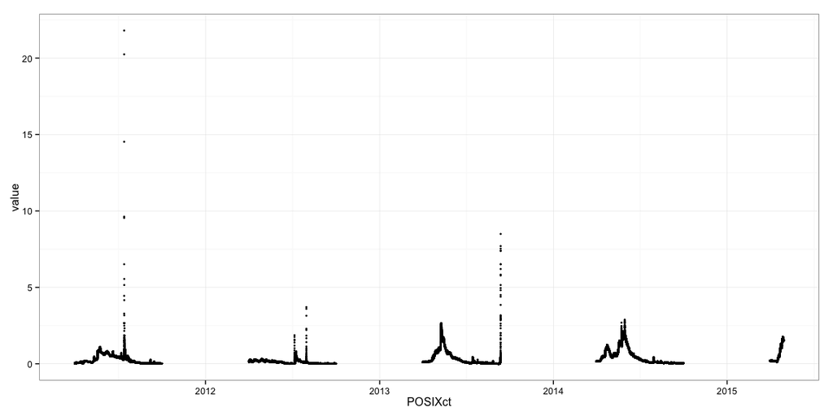

```r
oroPlot <- PlotPrettyUsgs(prettyOrodell)
```

Do this same as above, but for all sites in the HUC8. We restrict the plotting to just 3 locations so it’s legible for output here.

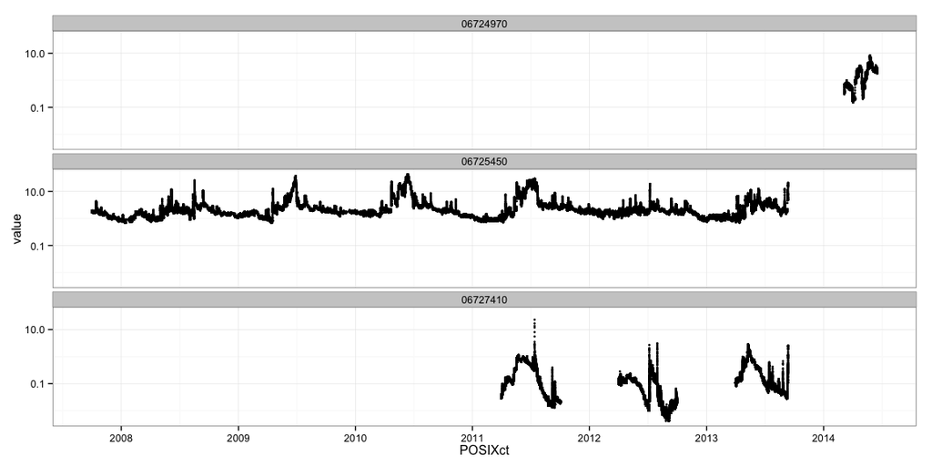

```r
siteInfo<-QuerySiteInfo(c('station_nm','site_no','state_cd'), path=dbPath)
dataCO <- PrettyUsgs(QuerySiteData(subset(siteInfo, state_cd=='08' & product=='00060')$site_no,
                                       product='00060', path=dbPath))
## 1:3 just to make the plot legible
coPlot <- PlotPrettyUsgs(subset(dataCO, site_no %in% unique(dataCO$site_no)[1:3]), plot=FALSE)
coPlot(yLog=TRUE)
```

We can also retrieve data from sites in different HUC8s.

```r
dataMultiHuc <- PrettyUsgs(QuerySiteData(c('06730500','02469800'), product='00060', path=dbPath))
str(dataMultiHuc)
```

```
## Classes 'prettyUsgs' and 'data.frame':   374243 obs. of  5 variables:
##  $ site_no : chr  "06730500" "06730500" "06730500" "06730500" ...
##  $ POSIXct : POSIXct, format: "2007-10-01 06:00:00" "2007-10-01 06:15:00" "2007-10-01 06:30:00" "2007-10-01 06:45:00" ...
##  $ code    : chr  "A" "A" "A" "A" ...
##  $ value   : num  0.51 0.51 0.51 0.51 0.51 ...
##  $ variable: chr  "Discharge (cms)" "Discharge (cms)" "Discharge (cms)" "Discharge (cms)" ...
##  - attr(*, "siteInfo")='data.frame': 2 obs. of  46 variables:
##   ..$ site_no              : chr  "06730500" "02469800"
##   ..$ agency_cd            : chr  "USGS" "USGS"
##   ..$ dec_lat_va           : num  40.1 31.7
##   ..$ dec_long_va          : num  -105 -88
##   ..$ huc_cd               : chr  "10190005" "03160203"
##   ..$ site_tp_cd           : chr  "ST" "ST"
##   ..$ state_cd             : chr  "08" "01"
##   ..$ station_nm           : chr  "BOULDER CREEK AT MOUTH NEAR LONGMONT, CO" "SATILPA CREEK NEAR COFFEEVILLE AL"
##   ..$ tz_cd                : chr  "MST" "CST"
##   ..$ lat_va               : num  400820 314439
##   ..$ long_va              : num  1050113 880121
##   ..$ coord_meth_cd        : chr  "N" "M"
##   ..$ coord_acy_cd         : chr  "5" "U"
##   ..$ coord_datum_cd       : chr  "NAD83" "NAD27"
##   ..$ dec_coord_datum_cd   : chr  "NAD83" "NAD83"
##   ..$ district_cd          : chr  "08" "01"
##   ..$ county_cd            : chr  "123" "025"
##   ..$ country_cd           : chr  "US" "US"
##   ..$ land_net_ds          : chr  "  NWSWS17 T002N R068W" ""
##   ..$ map_nm               : chr  "LONGMONT, CO" ""
##   ..$ map_scale_fc         : chr  "  24000" ""
##   ..$ alt_va               : num  4860 39.8
##   ..$ alt_meth_cd          : chr  "M" "U"
##   ..$ alt_acy_va           : num  10 0.01
##   ..$ alt_datum_cd         : chr  "NGVD29" "NGVD29"
##   ..$ basin_cd             : chr  "06" ""
##   ..$ topo_cd              : chr  "" ""
##   ..$ instruments_cd       : chr  "NNNNYNNNNNNNNNNNNNNNNNNNNNNNNN" "NNNNYNNNNNNNNNNNNNNNNNNNNNNNNN"
##   ..$ construction_dt      : chr  "" ""
##   ..$ inventory_dt         : chr  "" ""
##   ..$ drain_area_va        : num  447 164
##   ..$ contrib_drain_area_va: num  NA 164
##   ..$ local_time_fg        : chr  "Y" "Y"
##   ..$ reliability_cd       : chr  "" ""
##   ..$ gw_file_cd           : chr  "NYNNNNNN" "NNNNNNNN"
##   ..$ nat_aqfr_cd          : chr  "" ""
##   ..$ aqfr_cd              : chr  "" ""
##   ..$ aqfr_type_cd         : chr  "" ""
##   ..$ well_depth_va        : num  NA NA
##   ..$ hole_depth_va        : num  NA NA
##   ..$ depth_src_cd         : chr  "" ""
##   ..$ project_no           : chr  "" ""
##   ..$ timeZoneOffset       : chr  "-07:00" "-06:00"
##   ..$ srs                  : chr  "EPSG:4326" "EPSG:4326"
##   ..$ startTime            : POSIXct, format: "2007-10-01 06:00:00" "2007-10-01 05:00:00"
##   ..$ endTime              : POSIXct, format: "2015-04-29 21:00:00" "2015-04-29 21:00:00"
```

# GagesII Attributes

We’ve imported the gages-II atributes to be directly available in R.

```r
?gages2Attr
```

| gages2Attr | R Documentation |
| --- | --- |

## Gages-II attributes

### Description

These are the attributes taken from the USGS Gages-II data set.  
http://water.usgs.gov/GIS/metadata/usgswrd/XML/gagesII_Sept2011.xml  
The original gages-II atributes are in `gages2Attr` additional attributes may be placed in `gages2AttrPlus`.

### Usage

```r
gages2Attr
```

### Format

**STAID**

Station ID from USGS NWIS

**STANAME**

Station Name from USGS NWIS

**CLASS**

Classification (Ref or Non-ref)

**AGGECOREGI**

Aggregated ecoregion

**DRAIN_SQKM**

Drainage area, sq km

**HUC02**

Hydrologic Unit Code, 2-digit

**HUC08**

ONLY in gages2AttrPlus: Hydrologic Unit Code, 8-digit

**LAT_GAGE**

Latitude, decimal degrees

**LNG_GAGE**

Longitude, decimal degrees

**STATE**

State at gage location

**HCDN_2009**

If gage is part of HCDN-2009

**ACTIVE09**

If gage active in water year 2009

**FLYRS1900**

Number of complete years of flow data between 1900 and 2009

**FLYRS1950**

Number of complete years of flow data between 1950 and 2009

**FLYRS1990**

Number of complete years of flow data between 1990 and 2009

### Citation

Originator: James Falcone  
Publication_Date: 20111012  
Title: GAGES-II: Geospatial Attributes of Gages for Evaluating Streamflow  
Geospatial_Data_Presentation_Form: vector digital data Publication_Information:  
Publication_Place: Reston, Virginia  
Publisher: U.S. Geological Survey  
Online_Linkage: http://water.usgs.gov/lookup/getspatial?gagesII_Sept2011

### See Also

Other gages2: `gages2AttrPlus`

More specifically:

```r
str(gages2Attr)
```

```
## 'data.frame':    9322 obs. of  14 variables:
##  $ STAID     : chr  "01011000" "01013500" "01015800" "01016500" ...
##  $ STANAME   : chr  "Allagash River near Allagash, Maine" "Fish River near Fort Kent, Maine" "Aroostook River near Masardis, Maine" "MACHIAS RIVER NEAR ASHLAND, ME" ...
##  $ CLASS     : chr  "Non-ref" "Ref" "Non-ref" "Non-ref" ...
##  $ AGGECOREGI: chr  "NorthEast" "NorthEast" "NorthEast" "NorthEast" ...
##  $ DRAIN_SQKM: num  3187 2253 2314 848 4279 ...
##  $ HUC02     : chr  "01" "01" "01" "01" ...
##  $ LAT_GAGE  : num  47.1 47.2 46.5 46.6 46.8 ...
##  $ LNG_GAGE  : num  -69.1 -68.6 -68.4 -68.4 -68.2 ...
##  $ STATE     : chr  "ME" "ME" "ME" "ME" ...
##  $ HCDN_2009 : chr  "" "yes" "" "" ...
##  $ ACTIVE09  : chr  "yes" "yes" "yes" "" ...
##  $ FLYRS1900 : num  78 85 51 32 79 0 1 9 6 47 ...
##  $ FLYRS1950 : num  60 60 51 32 60 0 1 9 6 39 ...
##  $ FLYRS1990 : num  20 20 19 0 20 0 1 9 6 6 ...
```